# battle_clear-clear-data-checks

Inigo Peng, edited by Badhia Yunes-Katz

2025-07-09

# Database Tables

## battle_clear

### catch

**- Findings catch:**

- a lot of “not provided” values on EDI lifestage

#### Date Range Check

*EDI `date`*

```r
range(catch_battle_clear_edi$date)
```

```
## [1] "1998-10-09" "2025-04-02"
```

*DB `date`*

```
## [1] "1998-10-09" "2025-04-02"
```

#### ForkLength

*EDI `fork_length`*

- 0.1 % of values in the `fork_length` column are NA.

```
##    Min. 1st Qu.  Median    Mean 3rd Qu.    Max.    NA's
##    0.00   34.00   36.00   38.78   38.00  232.00     369
```

*DB `fork_length`*

- 0.1 % of values in the `fork_length` column are NA.

```
##    Min. 1st Qu.  Median    Mean 3rd Qu.    Max.    NA's
##    0.00   34.00   36.00   38.78   38.00  232.00     369
```

*Forklength Exploration Plots*

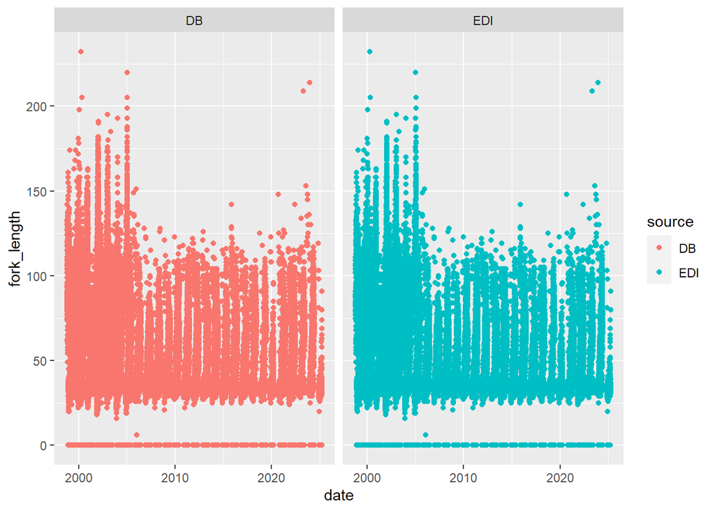

#### Lifestage

(life stage in edi data has not gone through wrangling)

*EDI `life_stage`*

- 0 % of values in the `life_stage` column from the EDI data are NA.

*DB `lifestage_id`*

- 0 % of values in the `lifestage_id` column from the database are NA.

#### Count

TODO: EDI data contains lifestage value “mixed” but not in lifestage lookuptable (resolved)

*EDI `count`*

- 0.1 % of values in the `count` column in edi data are NA.

```
##     Min.  1st Qu.   Median     Mean  3rd Qu.     Max.     NA's
##     0.00     1.00     1.00    19.54     1.00 84426.00      565
```

*DB `count`*

- 0.1 % of values in the `count` column in database data are NA.

```
##     Min.  1st Qu.   Median     Mean  3rd Qu.     Max.     NA's
##     0.00     1.00     1.00    19.54     1.00 84426.00      565
```

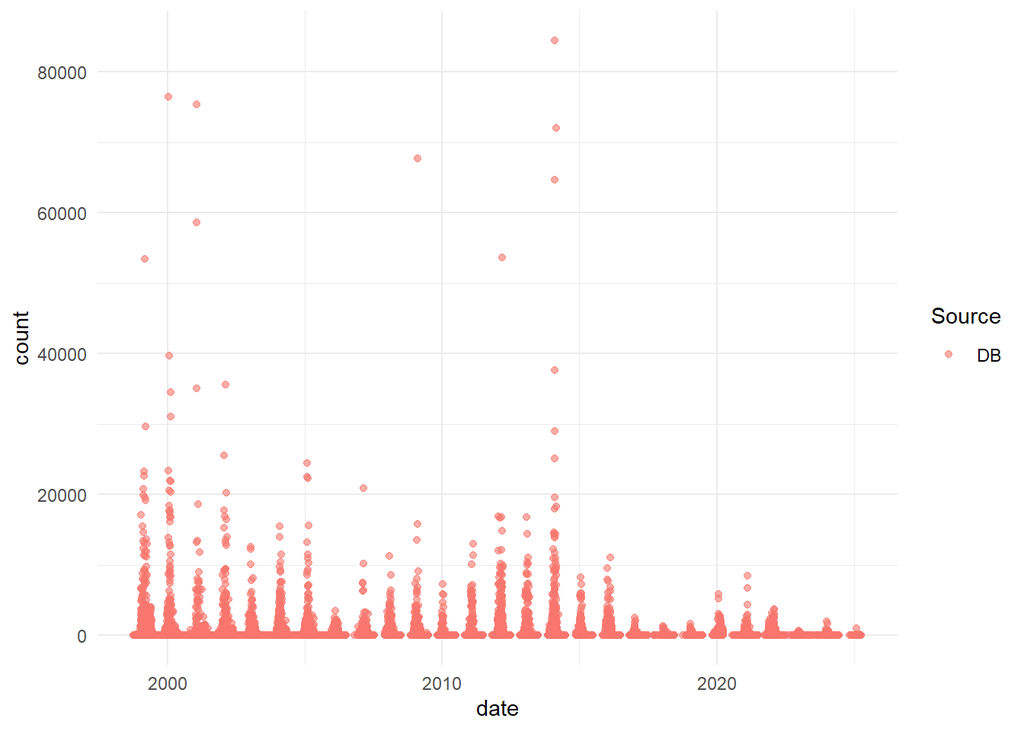

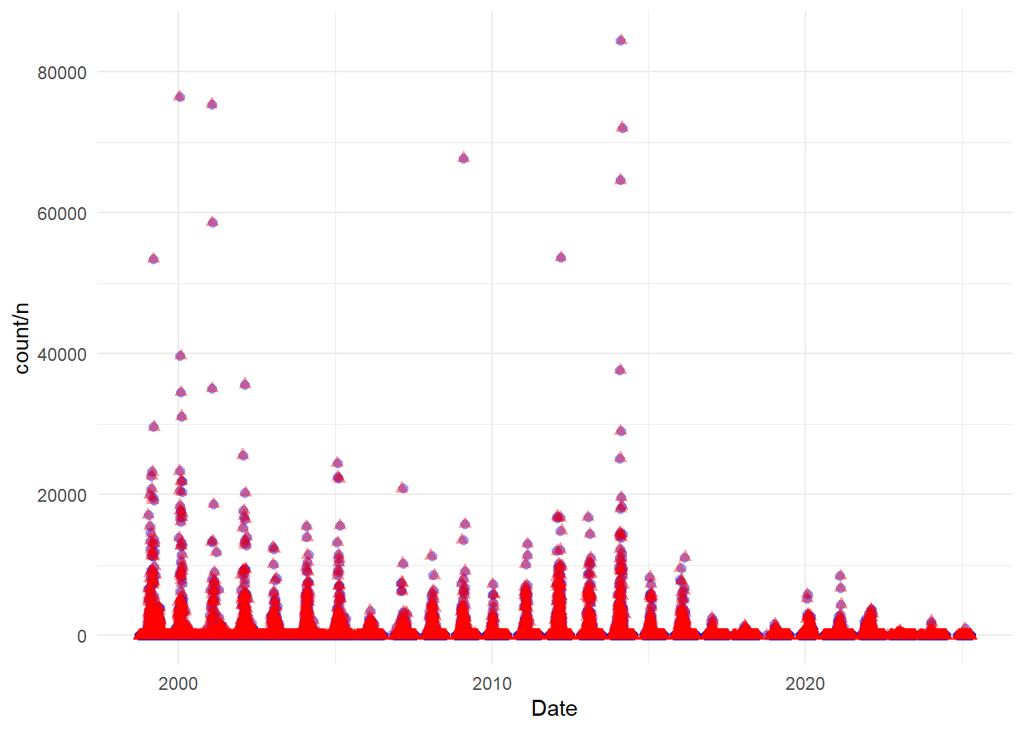

Random pick of data entry to compare between db and EDI

- test 1

```
## Rows: 1
## Columns: 17
## $ id               <int> 66634654
## $ catch_raw_id     <chr> "{292A0C58-FB5F-11D4-B974006008C01BCF}"
## $ trap_location_id <int> 14
## $ date             <date> 1999-01-17
## $ count            <dbl> 15
## $ run_id           <int> 3
## $ lifestage_id     <int> 4
## $ adipose_clipped  <lgl> FALSE
## $ dead             <lgl> NA
## $ fork_length      <dbl> 36
## $ weight           <dbl> 0
## $ actual_count     <lgl> NA
## $ updated_at       <dttm> 2025-07-08 22:56:14
## $ stream           <chr> "clear creek"
## $ site             <chr> "lcc"
## $ subsite          <chr> NA
## $ source           <chr> "DB"
```

```
## Rows: 1
## Columns: 17
## $ catch_row_id <chr> "{292A0C58-FB5F-11D4-B974006008C01BCF}"
## $ sample_id    <chr> "017_99"
## $ sample_date  <date> 1999-01-17
## $ station_code <chr> "lower clear creek"
## $ count        <dbl> 15
## $ r_catch      <dbl> 15
## $ fork_length  <dbl> 36
## $ weight       <dbl> 0
## $ fws_run      <chr> "fall"
## $ interp       <lgl> FALSE
## $ brood_year   <dbl> 1998
## $ subsample    <chr> NA
## $ common_name  <chr> "Chinook Salmon"
## $ life_stage   <chr> "not provided"
## $ stream       <chr> "battle clear creek"
## $ date         <date> 1999-01-17
## $ source       <chr> "EDI"
```

- test 2

```
## Rows: 1
## Columns: 17
## $ id               <int> 66635155
## $ catch_raw_id     <chr> "{2929F03F-FB5F-11D4-B974006008C01BCF}"
## $ trap_location_id <int> 14
## $ date             <date> 1999-03-09
## $ count            <dbl> 1
## $ run_id           <int> 3
## $ lifestage_id     <int> 4
## $ adipose_clipped  <lgl> FALSE
## $ dead             <lgl> NA
## $ fork_length      <dbl> 38
## $ weight           <dbl> 0
## $ actual_count     <lgl> NA
## $ updated_at       <dttm> 2025-07-08 22:56:14
## $ stream           <chr> "clear creek"
## $ site             <chr> "lcc"
## $ subsite          <chr> NA
## $ source           <chr> "DB"
```

```
## Rows: 1
## Columns: 17
## $ catch_row_id <chr> "{2929F03F-FB5F-11D4-B974006008C01BCF}"
## $ sample_id    <chr> "068_99"
## $ sample_date  <date> 1999-03-09
## $ station_code <chr> "lower clear creek"
## $ count        <dbl> 1
## $ r_catch      <dbl> 1
## $ fork_length  <dbl> 38
## $ weight       <dbl> 0
## $ fws_run      <chr> "fall"
## $ interp       <lgl> FALSE
## $ brood_year   <dbl> 1998
## $ subsample    <chr> NA
## $ common_name  <chr> "Chinook Salmon"
## $ life_stage   <chr> "not provided"
## $ stream       <chr> "battle clear creek"
## $ date         <date> 1999-03-09
## $ source       <chr> "EDI"
```

- test 3

```
## Rows: 1
## Columns: 17
## $ id               <int> 66637855
## $ catch_raw_id     <chr> "{4B85B5E1-9066-496A-A7F52185657FBFDE}"
## $ trap_location_id <int> 14
## $ date             <date> 2013-01-07
## $ count            <dbl> 1
## $ run_id           <int> 3
## $ lifestage_id     <int> 2
## $ adipose_clipped  <lgl> FALSE
## $ dead             <lgl> NA
## $ fork_length      <dbl> 37
## $ weight           <dbl> 0
## $ actual_count     <lgl> NA
## $ updated_at       <dttm> 2025-07-08 22:56:14
## $ stream           <chr> "clear creek"
## $ site             <chr> "lcc"
## $ subsite          <chr> NA
## $ source           <chr> "DB"
```

```
## Rows: 1
## Columns: 17
## $ catch_row_id <chr> "{4B85B5E1-9066-496A-A7F52185657FBFDE}"
## $ sample_id    <chr> "007_13"
## $ sample_date  <date> 2013-01-07
## $ station_code <chr> "lower clear creek"
## $ count        <dbl> 1
## $ r_catch      <dbl> 1
## $ fork_length  <dbl> 37
## $ weight       <dbl> 0
## $ fws_run      <chr> "fall"
## $ interp       <lgl> FALSE
## $ brood_year   <dbl> 2012
## $ subsample    <chr> NA
## $ common_name  <chr> "Chinook Salmon"
## $ life_stage   <chr> "obvious fry"
## $ stream       <chr> "battle clear creek"
## $ date         <date> 2013-01-07
## $ source       <chr> "EDI"
```

### Trap

**- Findings trap:**

```r
trap_battle_clear_edi <- read_csv("data-raw/edi-zips/battle_clear_trap.csv") |>
  mutate(stream="battle clear creek",
         date = as.Date(sample_date)) |>
  filter(!is.na(station_code)) |>
  arrange(trap_start_date) |>
  group_by(sample_id, station_code) |>
  slice_tail(n = 1)  |>
  ungroup() |> glimpse()
```

```
## Rows: 21,521
## Columns: 32
## $ sample_id          <chr> "001_00", "001_00", "001_01", "001_01", "001_01", "…
## $ sample_date        <date> 2000-01-01, 2000-01-01, 2001-01-01, 2001-01-01, 20…
## $ sample_time        <time> 08:00:00, 08:00:00, 09:25:00, 13:34:00, 08:30:00, …
## $ trap_start_date    <date> NA, NA, 2000-12-31, 2000-12-31, 2000-12-31, 2001-1…
## $ trap_start_time    <time>       NA,       NA, 08:40:00, 10:37:00, 08:02:00, …
## $ station_code       <chr> "lower clear creek", "upper battle creek", "lower b…
## $ depth_adjust       <dbl> NA, NA, 29, 29, 28, 30, 31, NA, 30, NA, 29, NA, NA,…
## $ avg_time_per_rev   <dbl> NA, NA, 9.70, 7.33, 15.30, 17.00, 17.00, NA, 0.00, …
## $ flow_start_meter   <dbl> NA, NA, NA, 100000, NA, NA, 963000, NA, 326000, NA,…
## $ flow_end_meter     <dbl> NA, NA, NA, 129313, NA, NA, 971103, NA, 334457, NA,…
## $ flow_set_time      <dbl> NA, NA, NA, 619, NA, 214, 180, NA, 240, NA, 240, NA…
## $ river_left_depth   <dbl> NA, NA, NA, NA, NA, NA, NA, NA, NA, NA, NA, NA, NA,…
## $ river_center_depth <dbl> NA, NA, NA, NA, NA, NA, NA, NA, NA, NA, NA, NA, NA,…
```

[output cut: 19 more lines]

#### Date Range Check

*DB `trap_visit_time_start`*

```
## [1] "1998-08-31 07:50:00 UTC" "2025-04-01 11:29:00 UTC"
```

*EDI `sample_date`*

```r
range(trap_battle_clear_edi$sample_date)
```

```
## [1] "1998-09-01" "2025-04-02"
```

#### water_velocity

*DB `water_velocity`*

- 16.8 % of values in the `water_velocity` column are NA.

```
##    Min. 1st Qu.  Median    Mean 3rd Qu.    Max.    NA's
##   0.000   2.100   2.610   3.292   3.360 483.450    3607
```

*EDI `velocity`* * 16.8 % of values in the `velocity` column are NA.

```
##    Min. 1st Qu.  Median    Mean 3rd Qu.    Max.    NA's
##   0.000   2.100   2.610   3.292   3.360 483.450    3606
```

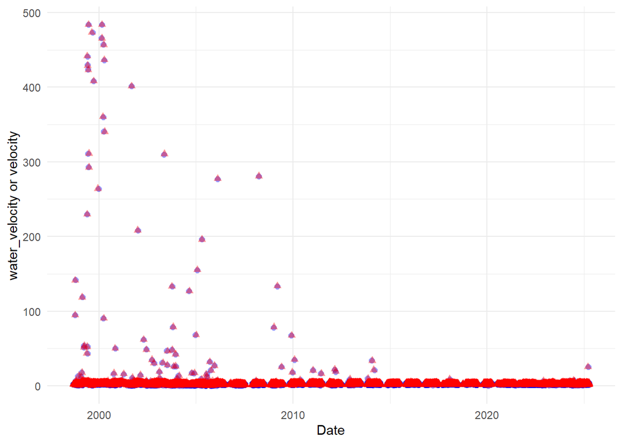

```r
trap_battle_clear_edi_clean<- trap_battle_clear_edi |>
  mutate(date = as.Date(sample_date),
         source = "EDI")
trap_battle_clear_db_clean <- trap_battle_clear_db |>
  mutate(date = as.Date(trap_visit_time_start),
         source = "DB")

ggplot() +
  geom_jitter(data = trap_battle_clear_db_clean,
              aes(x = date, y = water_velocity, color = source),
              color = "blue", alpha = 0.4, width = 10, height = 0.5, shape = 16, size = 2) +
  geom_jitter(data = trap_battle_clear_edi_clean,
              aes(x = date, y = velocity),
              color = "red", alpha = 0.4, width = 10, height = 0.5, shape = 17, size = 2) +
  theme_minimal() +
  labs(x = "Date",
       y = "water_velocity or velocity",
       color = "Source"
       )
```

### release

**- Findings release:**

- date ranges are the same
- all lifestage_id are NA in DB, and no similar field in EDI

#### Date Range Check

*DB `date_released`*

```
## [1] "2003-12-03 UTC" "2025-01-29 UTC"
```

*EDI `releaseTime`*

```r
range(release_battle_clear_edi$date)
```

```
## [1] "2003-12-03" "2025-01-29"
```

#### markedLifeStage

*EDI `* - no similar field

*DB `lifestage_id`*

- 100 % of values in the `lifestage_id` column are NA.

```
##    Min. 1st Qu.  Median    Mean 3rd Qu.    Max.    NA's
##      NA      NA      NA     NaN      NA      NA     854
```

#### nReleased

*EDI `number_released`*

- 0.4 % of values in the `number_released` column are NA.

```
##    Min. 1st Qu.  Median    Mean 3rd Qu.    Max.    NA's
##     8.0   292.0   389.0   359.2   428.5  1143.0       3
```

*DB `number_released`*

- 0.4 % of values in the `number_released` column are NA.

```
##    Min. 1st Qu.  Median    Mean 3rd Qu.    Max.    NA's
##     8.0   292.0   389.0   359.2   428.5  1143.0       3
```

#### median_fork_length_released

*EDI `median_fork_length_released`*

- 2 % of values in the `median_fork_length_released` column are NA.

```
##    Min. 1st Qu.  Median    Mean 3rd Qu.    Max.    NA's
##    0.00   36.00   37.00   38.32   38.00   78.00      17
```

*DB `median_fork_length_released`*

- 2 % of values in the `median_fork_length_released` column are NA.

```
##    Min. 1st Qu.  Median    Mean 3rd Qu.    Max.    NA's
##    0.00   36.00   37.00   38.32   38.00   78.00      17
```

*Exploration Plots*

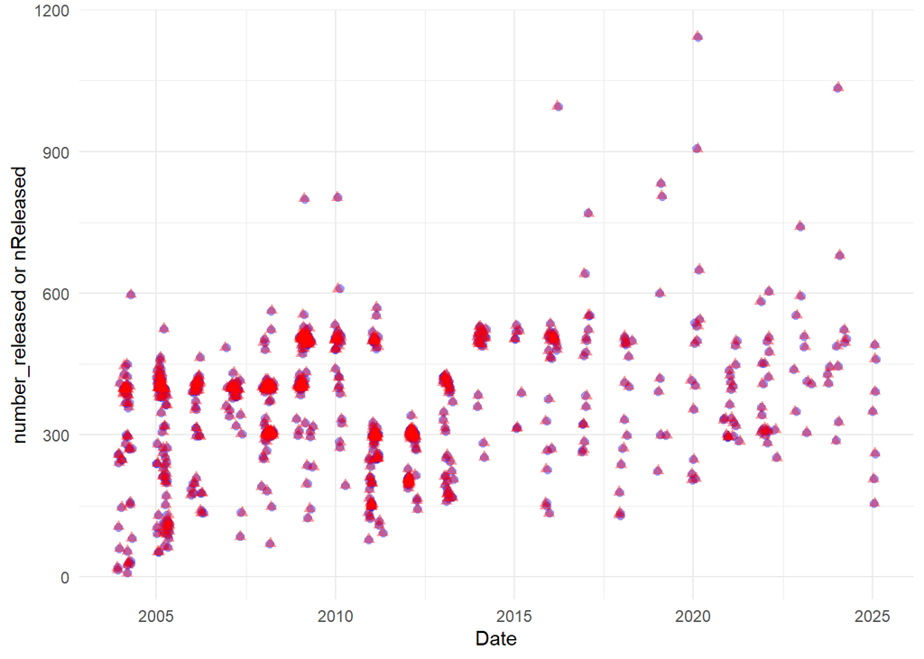

### releasefish

**- Findings releasefish:**

- no release fish table on EDI or DB

### releasefish

**- Findings recapture:**

- no release recapture table in DB